# Code is Law - COMPAS Case Study Impact of design decisions on outcome

```
0.6722222222222223
Number of COMPAS correct ones 746
Total number of correct ones: 968.0
0.6731481481481482
Number of COMPAS correct ones 561
Total number of correct ones: 727.0
#####################################
for cutoff 2
['True Pos.' 'False Pos.' 'True Neg.' 'False Neg.']
[0.2648638  0.2940262  0.30094778 0.07831222]
use iterative marker...
['race_black', 'race_white', 'race_hispanic', 'race_asian', 'race_native']
```

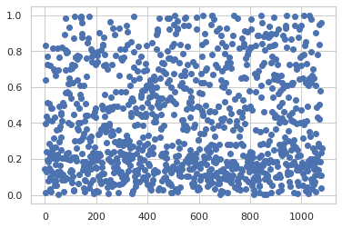

```
0.6715277777777777
Number of COMPAS correct ones 868
Total number of correct ones: 967.0
0.6712962962962963
Number of COMPAS correct ones 658
Total number of correct ones: 725.0
#####################################
for cutoff 3
['True Pos.' 'False Pos.' 'True Neg.' 'False Neg.']
[0.19990325 0.16976675 0.42520724 0.14327276]
use iterative marker...
['race_black', 'race_white', 'race_hispanic', 'race_asian', 'race_native']
```

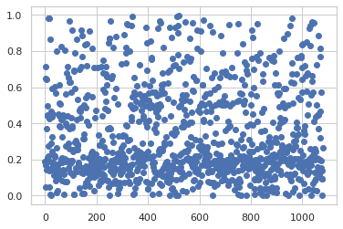

```
0.6770833333333334
Number of COMPAS correct ones 926
Total number of correct ones: 975.0
0.6907407407407408
Number of COMPAS correct ones 720
Total number of correct ones: 746.0
#####################################
for cutoff 4
['True Pos.' 'False Pos.' 'True Neg.' 'False Neg.']
[0.13634801 0.08799199 0.50698199 0.20682801]
use iterative marker...
['race_black', 'race_white', 'race_hispanic', 'race_asian', 'race_native']
```

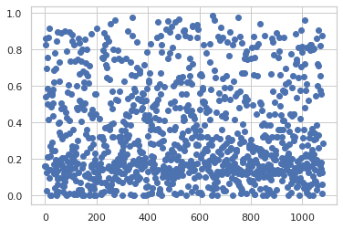

```
0.6659722222222222
Number of COMPAS correct ones 960
Total number of correct ones: 959.0
0.6768518518518518
Number of COMPAS correct ones 738
Total number of correct ones: 731.0
#####################################
for cutoff 5
['True Pos.' 'False Pos.' 'True Neg.' 'False Neg.']
[0.07857674 0.03711326 0.55786072 0.26459928]
use iterative marker...
['race_black', 'race_white', 'race_hispanic', 'race_asian', 'race_native']
```

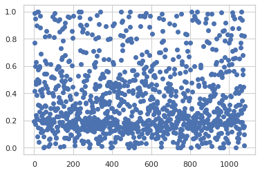

```
0.6652777777777777
Number of COMPAS correct ones 963
Total number of correct ones: 958.0
0.6953703703703704
Number of COMPAS correct ones 720
Total number of correct ones: 751.0
#####################################
for cutoff 6
['True Pos.' 'False Pos.' 'True Neg.' 'False Neg.']
[0.03748792 0.01258208 0.5823919  0.3056881 ]
use iterative marker...
['race_black', 'race_white', 'race_hispanic', 'race_asian', 'race_native']
```

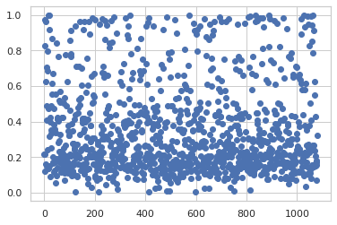

```
0.6694444444444444
Number of COMPAS correct ones 949
Total number of correct ones: 964.0
0.6944444444444444
Number of COMPAS correct ones 710
Total number of correct ones: 750.0
#####################################
for cutoff 7
['True Pos.' 'False Pos.' 'True Neg.' 'False Neg.']
[0.01172076 0.00255924 0.59241474 0.33145526]
use iterative marker...
['race_black', 'race_white', 'race_hispanic', 'race_asian', 'race_native']
```

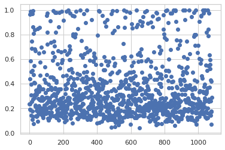

```
0.675
Number of COMPAS correct ones 928
Total number of correct ones: 972.0
0.6962962962962963
Number of COMPAS correct ones 698
Total number of correct ones: 752.0
#####################################
for cutoff 8
['True Pos.' 'False Pos.' 'True Neg.' 'False Neg.']
[1.48725592e-03 1.72744080e-04 5.94801240e-01 3.41688760e-01]
use iterative marker...
['race_black', 'race_white', 'race_hispanic', 'race_asian', 'race_native']
```

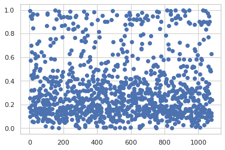

```
0.6638888888888889
Number of COMPAS correct ones 926
Total number of correct ones: 956.0
0.6805555555555556
Number of COMPAS correct ones 699
Total number of correct ones: 735.0
#####################################
for cutoff 9
['True Pos.' 'False Pos.' 'True Neg.' 'False Neg.']
[9.65108591e-06 3.48914085e-07 5.94973635e-01 3.43166365e-01]
use iterative marker...
['race_black', 'race_white', 'race_hispanic', 'race_asian', 'race_native']
```

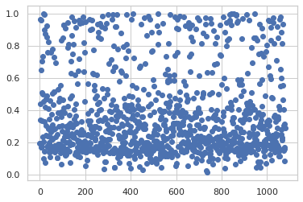

```
0.6722222222222223
Number of COMPAS correct ones 926
Total number of correct ones: 968.0
0.6768518518518518
Number of COMPAS correct ones 699
Total number of correct ones: 731.0
#####################################
Do training for compas_cuts
for cutoff 0
['True Pos.' 'False Pos.' 'True Neg.' 'False Neg.']
[0.33952914 0.56751086 0.         0.        ]
use iterative marker...
['race_black', 'race_white', 'race_hispanic', 'race_asian', 'race_native']
```

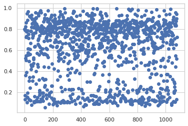

```
0.6743055555555556
Number of COMPAS correct ones 622
Total number of correct ones: 971.0
0.6842592592592592
Number of COMPAS correct ones 465
Total number of correct ones: 739.0
#####################################
for cutoff 1
['True Pos.' 'False Pos.' 'True Neg.' 'False Neg.']
[0.32363984 0.48106016 0.0864507  0.0158893 ]
use iterative marker...
['race_black', 'race_white', 'race_hispanic', 'race_asian', 'race_native']
```

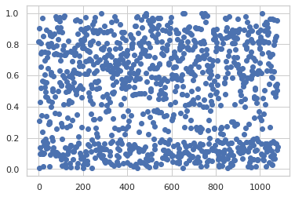

```
0.6611111111111111
Number of COMPAS correct ones 710
Total number of correct ones: 952.0
0.6685185185185185
Number of COMPAS correct ones 535
Total number of correct ones: 722.0
#####################################
for cutoff 2
['True Pos.' 'False Pos.' 'True Neg.' 'False Neg.']
[0.30193585 0.39761415 0.1698967  0.0375933 ]
use iterative marker...
['race_black', 'race_white', 'race_hispanic', 'race_asian', 'race_native']
```

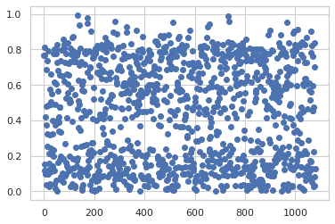

```
0.6763888888888889
Number of COMPAS correct ones 790
Total number of correct ones: 974.0
0.6851851851851852
Number of COMPAS correct ones 590
Total number of correct ones: 740.0
#####################################
for cutoff 3
['True Pos.' 'False Pos.' 'True Neg.' 'False Neg.']
[0.27372344 0.31580656 0.25170429 0.06580571]
use iterative marker...
['race_black', 'race_white', 'race_hispanic', 'race_asian', 'race_native']
```

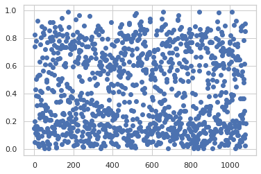

```
0.6722222222222223
Number of COMPAS correct ones 853
Total number of correct ones: 968.0
0.6833333333333333
Number of COMPAS correct ones 644
Total number of correct ones: 738.0
#####################################
for cutoff 4
['True Pos.' 'False Pos.' 'True Neg.' 'False Neg.']
[0.24125764 0.24254236 0.3249685  0.0982715 ]
use iterative marker...
['race_black', 'race_white', 'race_hispanic', 'race_asian', 'race_native']
```

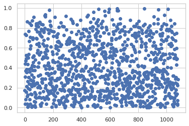

```
0.6631944444444444
Number of COMPAS correct ones 919
Total number of correct ones: 955.0
0.6583333333333333
Number of COMPAS correct ones 686
Total number of correct ones: 711.0
#####################################
for cutoff 5
['True Pos.' 'False Pos.' 'True Neg.' 'False Neg.']
[0.20650445 0.18017555 0.38733531 0.13302469]
use iterative marker...
['race_black', 'race_white', 'race_hispanic', 'race_asian', 'race_native']
```

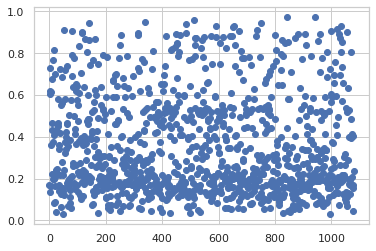

```
0.6708333333333333
Number of COMPAS correct ones 932
Total number of correct ones: 966.0
0.6898148148148148
Number of COMPAS correct ones 713
Total number of correct ones: 745.0
#####################################
for cutoff 6
['True Pos.' 'False Pos.' 'True Neg.' 'False Neg.']
[0.1663404  0.1227296  0.44478126 0.17318874]
use iterative marker...
['race_black', 'race_white', 'race_hispanic', 'race_asian', 'race_native']
```

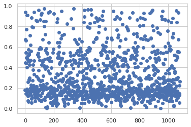

```
0.6722222222222223
Number of COMPAS correct ones 963
Total number of correct ones: 968.0
0.6796296296296296
Number of COMPAS correct ones 730
Total number of correct ones: 734.0
#####################################
for cutoff 7
['True Pos.' 'False Pos.' 'True Neg.' 'False Neg.']
[0.12506914 0.07648086 0.49103    0.21446   ]
use iterative marker...
['race_black', 'race_white', 'race_hispanic', 'race_asian', 'race_native']
```

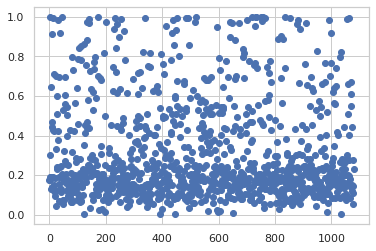

```
0.6555555555555556
Number of COMPAS correct ones 962
Total number of correct ones: 944.0
0.6805555555555556
Number of COMPAS correct ones 732
Total number of correct ones: 735.0
#####################################
for cutoff 8
['True Pos.' 'False Pos.' 'True Neg.' 'False Neg.']
[0.07490997 0.03453003 0.53298083 0.26461917]
use iterative marker...
['race_black', 'race_white', 'race_hispanic', 'race_asian', 'race_native']
```

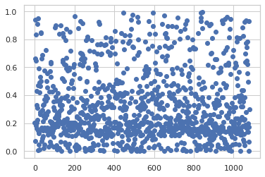

```
0.6604166666666667
Number of COMPAS correct ones 965
Total number of correct ones: 951.0
0.6898148148148148
Number of COMPAS correct ones 718
Total number of correct ones: 745.0
#####################################
for cutoff 9
['True Pos.' 'False Pos.' 'True Neg.' 'False Neg.']
[3.12948290e-03 4.50517097e-04 5.67060339e-01 3.36399661e-01]
use iterative marker...
['race_black', 'race_white', 'race_hispanic', 'race_asian', 'race_native']
```

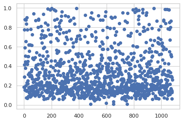

```
0.6763888888888889
Number of COMPAS correct ones 926
Total number of correct ones: 974.0
0.6851851851851852
Number of COMPAS correct ones 699
Total number of correct ones: 740.0
#####################################
```

Now that we trained our/loaded our model, we can see that it manages to find a pattern within the data useful for correction. And, as the binning strategy is so central, its performance varies depending on the binning strategy employed. Let us compare it directly to COMPAS:

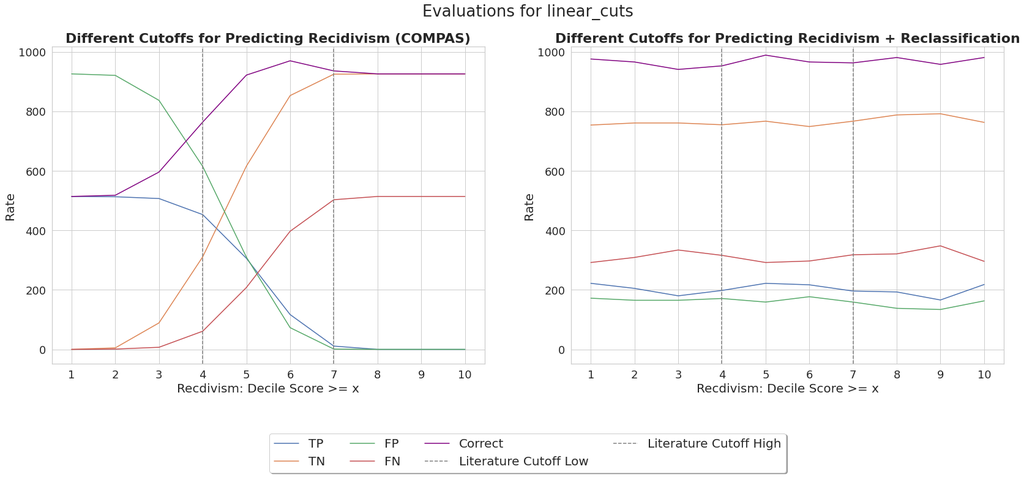

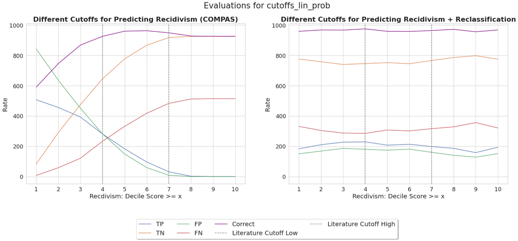

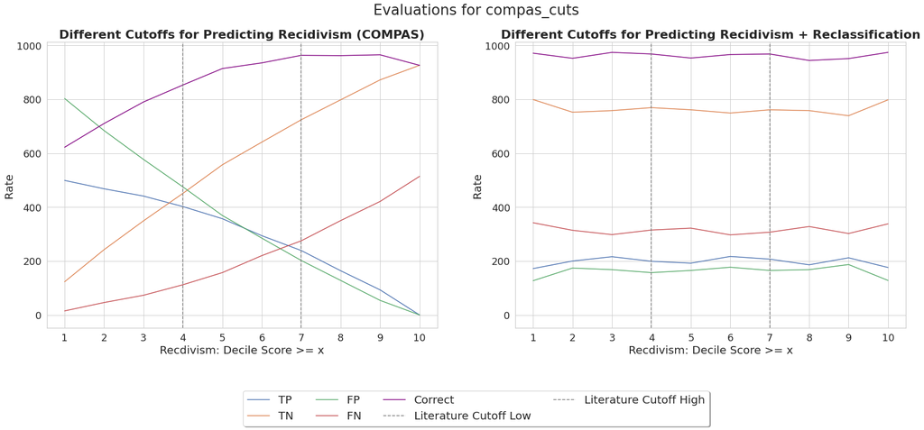

Let us first look at the last figure, directly above. On the left, we always find the COMPAS performance with respect to the threshold shown on the x-xis. The y-axis shows the absolute number of people - absolute so that is obvious what the specific trade-off is.

For the proposed literature threshold at 4, COMPAS makes more False Positives than True Positives. At the second proposed threshold, 7, the trade-off is only marginally better. In principle, the total number reaches its maximum for the threshold 7.  
That means, for the threshold 4 for which COMPAS already recommends 'supervision', we mainly jail innocents.

Looking at the performance of our correction model, we see that the threshold becomes mostly irrelevant. Moreorver, we find always more True Positives than False Positives (FP). On the other hand, we also always make more False Negatives (FN) than TP. That means we find fewer recidivists for jailing compared to those recidivists we let falsely go.

Hence, our *solution is **not** better* (although accuracy is higher on average). Normatively, we simply *offer another solution on the pareto front*. That is important, as the *normative underpinnings* of a parliament or a judge *should decide* on the trade-off between errors (FP vs. FN). COMPAS, however, obscures the fact that the it implicitly makes such a decision as the most accurate result is achieved when we do not imprison/jail most defendants.

Consequently:

- COMPAS onscures a normative choice for the trade-off between FP and FN.
- The binning strategy obscures another normative trade-off.
- It is possible to invert the FP/FN trade-off with a correction model, i.e. offer another solution on the pareto-front.

Now, we look again at our subgroups and how they are impacted in terms of false positives and false negatives in order to asses fairness.

```
Fairness analyis for binning strategy linear_cuts
```

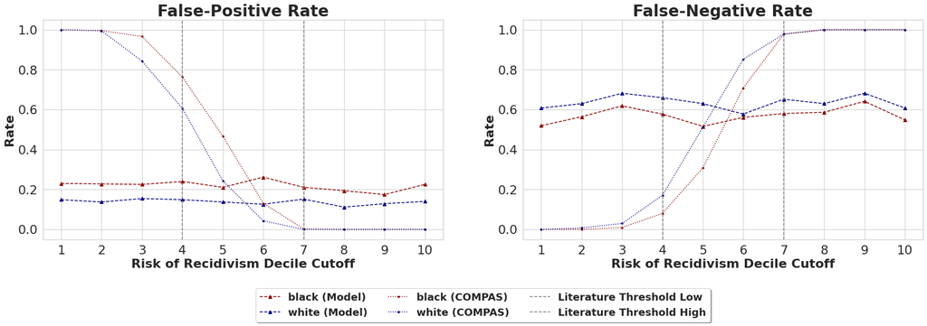

```
Fairness analyis for binning strategy cutoffs_lin_prob
```

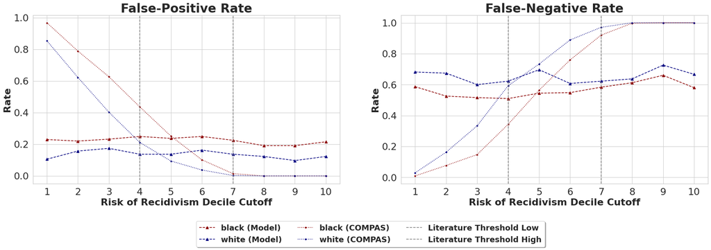

```
Fairness analyis for binning strategy compas_cuts
```

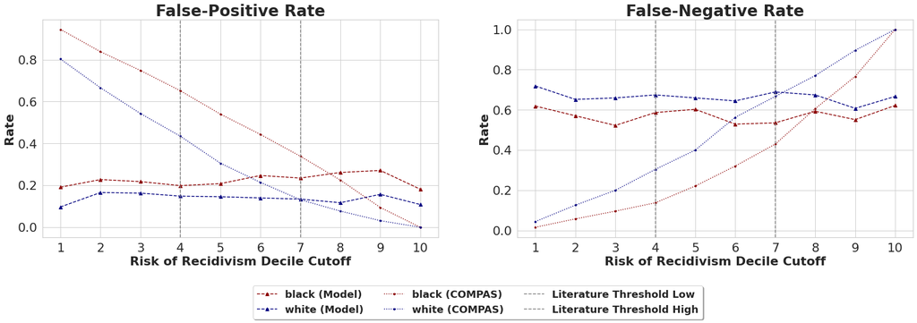

We see a varying impact of the model on the outcome. While COMPAS is always disfavoring black individuals, the strength of that effect depends on the binning strategy. As such, the COMPAS binning strategy is acutally the one disfavoring black individuals most (greatest distance between lines). On the other hand, the correction model reduces the amount of disfavor. It reduces it most for the COMPAS binning and least for the uniformly spaced raw score bins.

Overall, it reduces the false positive error rate (in absolutes) wile rising the false negative level. Relatvely, it reduces disfavor towards black individuals.

```
Fairness analyis for binning strategy linear_cuts
```

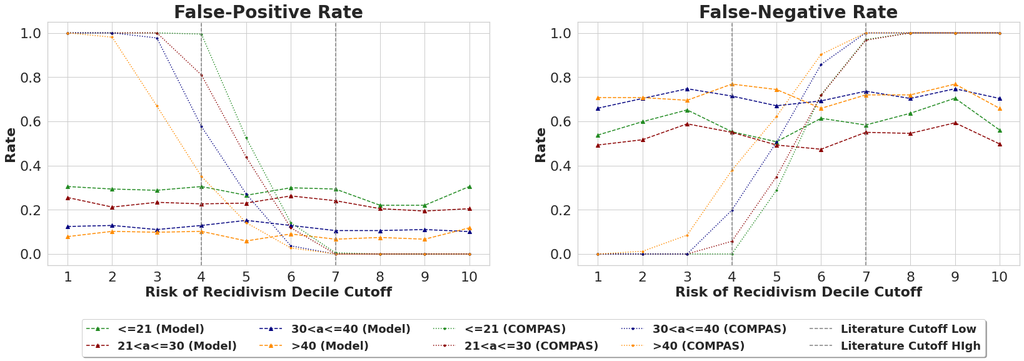

```
Fairness analyis for binning strategy cutoffs_lin_prob
```

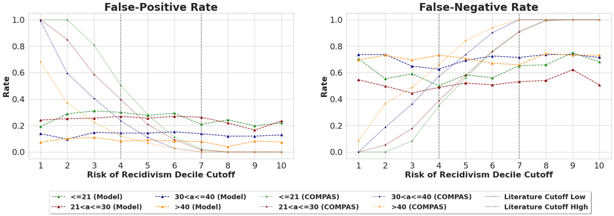

```
Fairness analyis for binning strategy compas_cuts
```

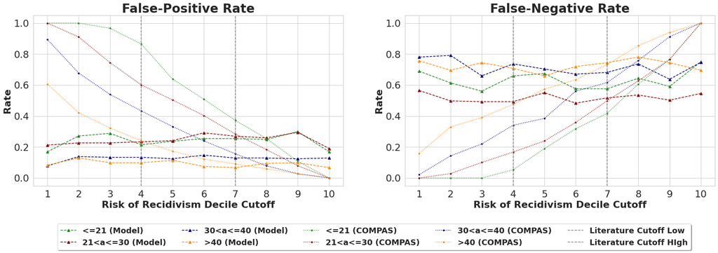

Is that better? That depends on who you ask - but that is the important take-away here:  
It should really be a decision made by society and/or a judge - hence *a **private** company should **not be allowed** to simply make those design decisions.*